# Cours 12 : Réseaux de neurones

**Loïc Grobol** lgrobol@parisnanterre.fr

2021-11-10

```python
from IPython.display import display, Markdown
```

```python
import numpy as np
import matplotlib.pyplot as plt
```

## Le perceptron simple

[figure not shown]

Un modèle de neurone biologique (plutôt sensoriel) : une unité qui reçoit plusieurs entrées $x_i$ scalaires (des nombres quoi), en calcule une somme pondérée $z$ (avec des poids $w_i$ prédéfinis) et renvoie une sortie binaire $y$ ($1$ si $z$ est positif, $0$ sinon).

Autrement dit

$$\begin{align} z &= \sum_i w_ix_i\\ y &= \begin{cases} 1 & \text{si $z > 0$}\\ 0 & \text{sinon} \end{cases} \end{align}$$

Formulé célèbrement par McCulloch et Pitts (1943) avec des notations différentes

**Attention** selon les auteurices, le cas $z=0$ est traité différemment, pour *Speech and Language Processing*, on renvoie $0$ dans ce cas, c'est donc la convention qu'on suivra, mais vérifiez à chaque fois.

On peut ajouter un terme de *biais* en fixant $x_0=1$ et $w_0=b$, ce qui donne

$$\begin{equation} z = \sum_{i=0}^n w_ix_i = \sum_{i=1}^n w_ix_i + b \end{equation}$$

Ou schématiquement

[figure not shown]

Ou avec du code

```python
def perceptron(inpt, weights):
    """Calcule la sortie du perceptron dont les poids sont `weights` pour l'entrée `inpt`

    Entrées :

    - `inpt` un tableau numpy de dimension $n$
    - `weights` un tableau numpy de dimention $n+1$

    Sortie: un tableau numpy de type booléen et de dimensions $0$
    """
    return (np.inner(weights[1:], inpt) + weights[0]) > 0
```

Implémenté comme une machine, le perceptron Mark I, par Rosenblatt (1958) :

[figure not shown]

**Est-ce que ça vous rappelle quelque chose ?**

🤔

C'est un **classifieur linéaire** dont on a déjà parlé précédemment.

Les ambitions initiales étaient grandes

> *the embryo of an electronic computer that [the Navy] expects will be able to walk, talk, see, write, reproduce itself and be conscious of its existence.*  
> New York Times, rappporté par Olazaran (1996)

C'est par exemple assez facile de construire un qui réalis l'opération logique élémentaire $\operatorname{ET}$ :

```python
and_weights = np.array([-0.6, 0.5, 0.5])
print("x\ty\tx ET y")
for x_i in [0, 1]:
    for y_i in [0, 1]:
        out = perceptron([x_i, y_i], and_weights).astype(int)
        print(f"{x_i}\t{y_i}\t{out}")
```

```
x	y	x ET y
0	0	0
0	1	0
1	0	0
1	1	1
```

Ça marche bien parce que c'est un problème **linéairement séparable** : si on représente $x$ et $y$ dans le plan, on peut tracer une droite qui sépare la parties où $x\operatorname{ET}y$ vaut $1$ et la partie où ça vaut $0$ :

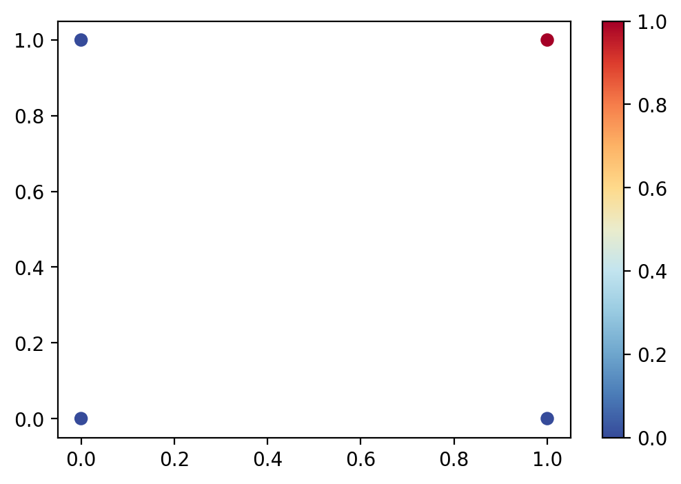

```python
import tol_colors as tc

x = np.array([0, 1])
y = np.array([0, 1])
X, Y = np.meshgrid(x, y)
Z = np.logical_and(X, Y)

fig = plt.figure(dpi=200)

heatmap = plt.scatter(X, Y, c=Z, cmap=tc.tol_cmap("sunset"))
plt.colorbar(heatmap)
plt.show()
```

Ici voilà les valeurs que renvoie notre neurone :

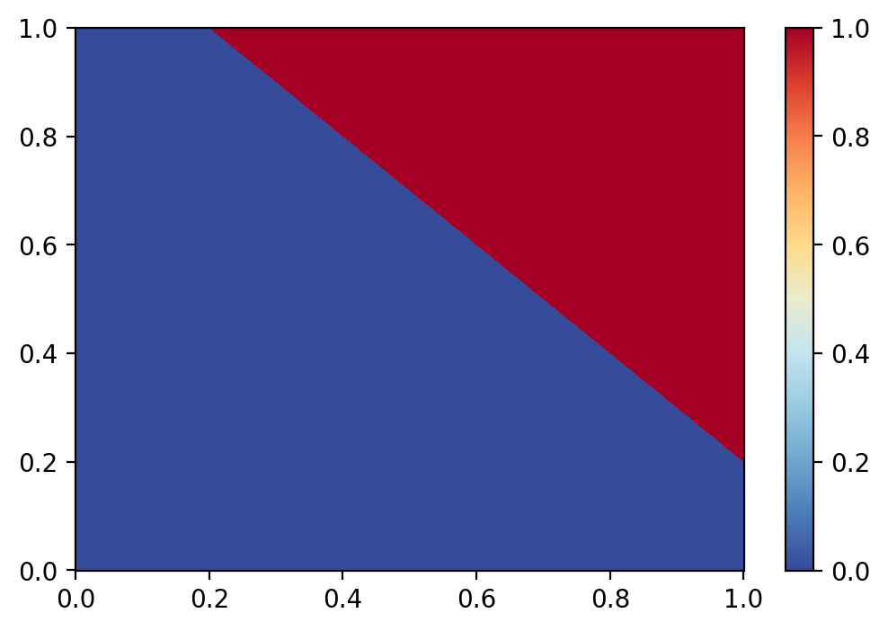

```python
import tol_colors as tc

x = np.linspace(0, 1, 1000)
y = np.linspace(0, 1, 1000)
X, Y = np.meshgrid(x, y)
Z = 0.5*X + 0.5*Y - 0.6 > 0

fig = plt.figure(dpi=200)

heatmap = plt.pcolormesh(X, Y, Z, shading="auto", cmap=tc.tol_cmap("sunset"))
plt.colorbar(heatmap)
plt.show()
```

On confirme : ça marche !

Ça marche aussi très bien pour $\operatorname{OU}$ et $\operatorname{NON}$

```python
or_weights = np.array([-0.5, 1, 1])
print("x\ty\tx OU y")
for x_i in [0, 1]:
    for y_i in [0, 1]:
        out = perceptron([x_i, y_i], or_weights).astype(int)
        print(f"{x_i}\t{y_i}\t{out}")
```

```
x	y	x OU y
0	0	0
0	1	1
1	0	1
1	1	1
```

```python
not_weights = np.array([1, -1])
print("x\tNON x")
for x_i in [0, 1]:
    out = perceptron([x_i], not_weights).astype(int)
    print(f"{x_i}\t{out}")
```

```
x	NON x
0	1
1	0
```

Mais on se heurte vite à des problèmes, même pour représenter les fonctions logiques les plus basiques, comme $\operatorname{XOR}$ définie pour $x ∈ \{0, 1\}$ et $y ∈ \{0, 1\}$ par :

$$\begin{equation} \operatorname{XOR}(x, y) = \begin{cases} 1 & \text{si $x ≠ y$}\\ 0 & \text{si $x = y$} \end{cases} \end{equation}$$

Autrement dit, $\operatorname{XOR}(x, y)$ c'est vrai si $x$ est vrai ou si $y$ est vrai, mais pas si les deux sont vrais en même temps.

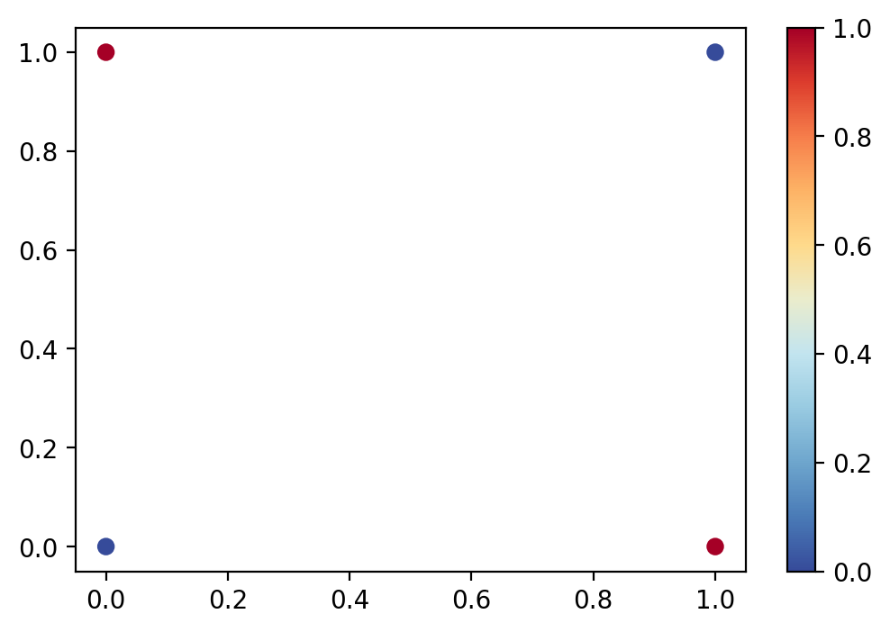

```python
import tol_colors as tc

x = np.array([0, 1])
y = np.array([0, 1])
X, Y = np.meshgrid(x, y)
Z = np.logical_xor(X, Y)

fig = plt.figure(dpi=200)

heatmap = plt.scatter(X, Y, c=Z, cmap=tc.tol_cmap("sunset"))
plt.colorbar(heatmap)
plt.show()
```

Si on l'étend à tout le plan pour mieux voir en prenant $0.5$ comme frontière pour *vrai* :

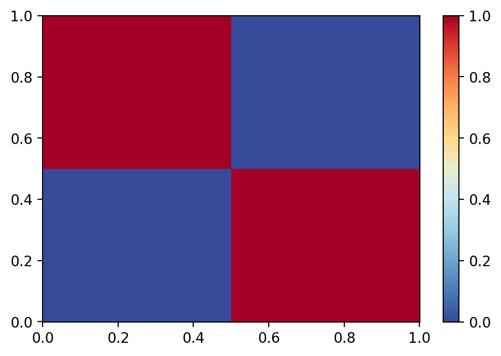

```python
import tol_colors as tc

x = np.linspace(0, 1, 1000)
y = np.linspace(0, 1, 1000)
X, Y = np.meshgrid(x, y)
Z = np.logical_xor(X > 0.5, Y > 0.5)

fig = plt.figure(dpi=200)

heatmap = plt.pcolormesh(X, Y, Z, shading="auto", cmap=tc.tol_cmap("sunset"))
plt.colorbar(heatmap)
plt.show()
```

On voit clairement le hic : ce n'est pas un problème linéairement séparable, donc un classifieur linéaire ne sera jamais capable de le résoudre.

## Réseaux de neurones

Comment on peut s'en sortir ? En combinant des neurones !

On sait faire les portes logiques élémentaires $\operatorname{ET}$, $\operatorname{OU}$ et $\operatorname{NON}$, or on a

$$\begin{equation} x \operatorname{XOR} y = (x \operatorname{OU} y)\quad\operatorname{ET}\quad\operatorname{NON}(x \operatorname{ET} y) \end{equation}$$

Ou en notation fonctionnelle

$$\begin{equation} \operatorname{XOR}(x, y) = \operatorname{ET}\left[\operatorname{OU}(x, y), \operatorname{NON}(\operatorname{ET}(x,y))\right] \end{equation}$$

On peut donc avoir $\operatorname{XOR}$ non pas avec un seul neurone, mais avec plusieurs neurones mis en **réseau**

[figure not shown]

Ou, en écrivant les termes de biais dans les neurones et en ajoutant un neurone pour servir de relai

[figure not shown]

On appelle cette structure un réseau de neurones **complètement connecté** ou **dense**. On parle aussi un peu abusivement de *perceptron multicouches*. En anglais **multilayer perceptron** ou **feedforward neural network**.

Voyons sa frontière de décision

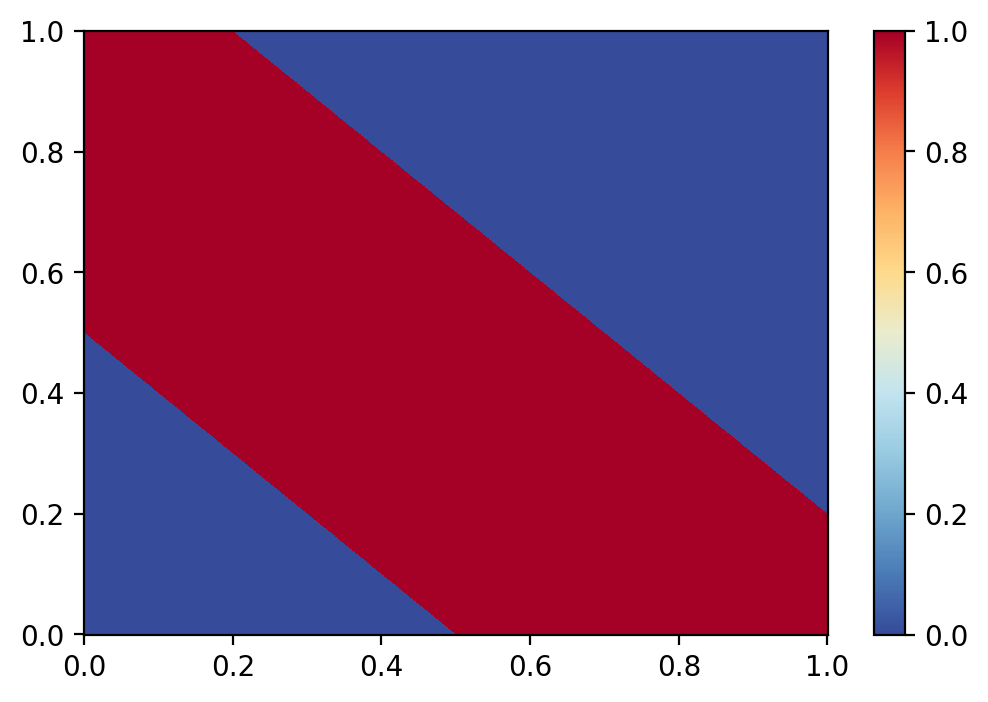

```python
import tol_colors as tc

def and_net(X, Y):
    return 0.5*X + 0.5*Y - 0.6 > 0

def or_net(X, Y):
    return X + Y - 0.5 > 0

def not_net(X):
    return -1*X + 1 > 0

x = np.linspace(0, 1, 1000)
y = np.linspace(0, 1, 1000)
X, Y = np.meshgrid(x, y)
Z = and_net(or_net(X, Y), not_net(and_net(X, Y)))

fig = plt.figure(dpi=200)

heatmap = plt.pcolormesh(X, Y, Z, shading="auto", cmap=tc.tol_cmap("sunset"))
plt.colorbar(heatmap)
plt.show()
```

Ça marche !

Enfin ça marche pour les coins, mais c'est tout ce qui nous intéressait !

## Les couches

Une autre façon de voir ces couches neuronales qui va être bien pratique pour la suite, c'est de voir chaque couche comme une fonction qui renvoie autant de sorties qu'elle a de neurones et prend autant d'entrées qu'il y a de neurones dans la couche précédente. Par exemple la première couche notre réseau $\operatorname{XOR}$ peut s'écrire comme :

```python
def layer1(inpt):
    output_1 = ((np.inner(inpt, np.array([0.5, 0.5])) + np.array(-0.6)) > 0).astype(int)
    output_2 = ((np.inner(inpt, np.array([1, 1])) + np.array(-0.5)) > 0).astype(int)
    return np.hstack([output_1, output_2])

display(layer1([1, 0]))
display(layer1([1, 1]))
```

```
array([0, 1])
```

```
array([1, 1])
```

La deuxième couche comme :

```python
def layer2(inpt):
    output_1 = ((np.inner(inpt, np.array([-1, 0])) + np.array(1)) > 0).astype(int)
    output_2 = ((np.inner(inpt, np.array([0, 1])) + np.array(0)) > 0).astype(int)
    return np.hstack([output_1, output_2])

display(layer2([0, 1]))
display(layer2([1, 1]))
```

```
array([1, 1])
```

```
array([0, 1])
```

Et la troisième couche comme

```python
def layer3(inpt):
    return ((np.inner(inpt, np.array([0.5, 0.5])) + np.array(-0.6)) > 0).astype(int)

display(layer3([1, 1]))
display(layer3([0, 1]))
```

```
1
```

```
0
```

Le réseau c'est donc

```python
def xor_ffnn(inpt):
    return layer3(layer2(layer1(inpt)))

print("x\ty\tx XOR y")
for x_i in [0, 1]:
    for y_i in [0, 1]:
        out = xor_ffnn([x_i, y_i]).astype(int)
        print(f"{x_i}\t{y_i}\t{out}")
```

```
x	y	x XOR y
0	0	0
0	1	1
1	0	1
1	1	0
```

Maintenant, si on regarde, ces fonctions ont toutes la même tête, on pourrait le faire en une seule

```python
def layer(inpt, weight1, bias1, weight2, bias2):
    output_1 = ((np.inner(inpt, weight1) + bias1) > 0).astype(int)
    output_2 = ((np.inner(inpt, weight2) + bias2) > 0).astype(int)
    return np.hstack([output_1, output_2])

layer([1, 0], [0.5, 0.5], -0.6, [1, 1], -0.5)
```

```
array([0, 1])
```

On peut rassembler ensemble les poids

```python
def layer(inpt, weight, bias):
    output_1 = ((np.inner(inpt, weight[0]) + bias[0]) > 0).astype(int)
    output_2 = ((np.inner(inpt, weight[1]) + bias[1]) > 0).astype(int)
    return np.hstack([output_1, output_2])

layer([0, 1], [[0.5, 0.5], [1, 1]], [-0.5, -0.6])
```

```
array([0, 1])
```

Et même, en l'écrivant comme des opérations matricielles

```python
def layer(inpt, weight, bias):
    output = ((np.matmul(weight, inpt) + bias) > 0).astype(int)
    return output

layer([0, 1], [[0.5, 0.5], [1, 1]], [-0.5, -0.6])
```

```
array([0, 1])
```

Cette dernière formulation est celle qu'on utilise en général, elle a le gros avantage de très bien se paralléliser, et même, si on dispose de matériel spécialisé, comme des cartes graphiques) de bénéficier d'accélérations supplémentaires (voir par exemple Vuduc et Choi ([2013](https://jeewhanchoi.github.io/publication/pdf/brief_history.pdf)) pour la culture).

Elle permet aussi de facilement manipuler les tailles des couches : une couche à $n$ entrées et $m$ sorties correspond à une matrice de poids de taille $m×n$ et un vecteur de biais de taille $m$.

Une dernière subtilité ? Pour matérialiser le concept de couche et éviter d'avoir à passer en permanence des poids, on utilise en général des classes. Voici notre réseau $\operatorname{XOR}$ réécrit en objet :

```python
class Layer:
    """Une couche neuronale complètement connectée"""
    def __init__(self, weight, bias):
        self.weight = weight
        self.bias = bias

    def __call__(self, inpt):
        return ((np.matmul(self.weight, inpt) + self.bias) > 0).astype(int)

layer1 = Layer(
    np.array([[0.5, 0.5], [1, 1]]),
    np.array([-0.6, -0.5]),
)
display(layer1([0,1]))
layer2 = Layer(np.array([[-1, 0], [0, 1]]), np.array([1, 0]))
layer3 = Layer(np.array([0.5, 0.5]), np.array(-0.6))

def xor_ffnn(inpt):
    return layer3(layer2(layer1(inpt)))

print("x\ty\tx XOR y")
for x_i in [0, 1]:
    for y_i in [0, 1]:
        out = xor_ffnn([x_i, y_i])
        print(f"{x_i}\t{y_i}\t{out}")
```

```
array([0, 1])
```

```
x	y	x XOR y
0	0	0
0	1	1
1	0	1
1	1	0
```

(admirez au passage l'usage de `__call__`)

On peut aussi imaginer un conteneur pour une réseau

```python
class Network:
    def __init__(self, layers):
        self.layers = layers

    def __call__(self, inpt):
        res = inpt
        for l in self.layers:
            res = l(res)
        return res

xor_ffnn = Network([layer1, layer2, layer3])

print("x\ty\tx XOR y")
for x_i in [0, 1]:
    for y_i in [0, 1]:
        out = xor_ffnn([x_i, y_i])
        print(f"{x_i}\t{y_i}\t{out}")
```

```
x	y	x XOR y
0	0	0
0	1	1
1	0	1
1	1	0
```

Ça fait propre, non ?

## Non-linearités

Comme pour les classifieurs logistiques, on aime bien en général avoir une décision qui ne soit pas tout ou rien mais puisse prédire des nombres, pour ça on peut remplacer le `> 0` dans ce qui précède par la fonction logistique

```python
def sigmoid(x):
    return 1/(1+np.exp(-x))

class SigmoidLayer:
    """Une couche neuronale complètement connectée suivie de la fonction logistique"""
    def __init__(self, weight, bias):
        self.weight = weight
        self.bias = bias

    def __call__(self, inpt):
        return sigmoid(np.matmul(self.weight, inpt) + self.bias)

soft_and = SigmoidLayer(np.array([0.5, 0.5]), np.array(-0.6))

print("x\ty\tx soft_and y")
for x_i in [0, 1]:
    for y_i in [0, 1]:
        out = soft_and([x_i, y_i])
        print(f"{x_i}\t{y_i}\t{out}")
```

```
x	y	x soft_and y
0	0	0.35434369377420455
0	1	0.47502081252106
1	0	0.47502081252106
1	1	0.598687660112452
```

On peut aussi l'imaginer comme la succession d'une couche purement linéaire et d'une couche qui applique la fonction logistique sur ses entrées coordonnée par coordonnée :

```python
class LinearLayer:
    """Une couche neuronale linéaire complètement connectée"""
    def __init__(self, weight, bias):
        self.weight = weight
        self.bias = bias

    def __call__(self, inpt):
        return np.matmul(self.weight, inpt) + self.bias

class SigmoidLayer:
    """Une couche neuronale qui applique la fonction logistique aux coordonnées de son entrée"""
    # Pas besoin d'un `__init__` particulier ici, on a pas de paramètres à initialiser
    def __call__(self, inpt):
        return 1/(1+np.exp(-inpt))

soft_and = Network(
    [
        LinearLayer(np.array([0.5, 0.5]), np.array(-0.6)),
        SigmoidLayer(),
    ],
)

print("x\ty\tx soft_and y")
for x_i in [0, 1]:
    for y_i in [0, 1]:
        out = soft_and([x_i, y_i])
        print(f"{x_i}\t{y_i}\t{out}")
```

```
x	y	x soft_and y
0	0	0.35434369377420455
0	1	0.47502081252106
1	0	0.47502081252106
1	1	0.598687660112452
```

Dans le cas général, on dit que la fonction logistique dans ce réseau est une **non-linéarité** ou **activation**, c'est-à-dire une fonction non-linéaire appliquée coordonnée par coordonnée aux sorties d'une couche neuronale. On peut en choisir une autre, selon ce qu'on veut obtenir.

Pour les couches de sorties, c'est souvent l'application ciblée qui va conditionner ce choix, pour les couches internes, dites **couches cachées**, elle conditionnent la capacité d'apprentissage du réseau. Voici quelques uns des exemples les plus courants :

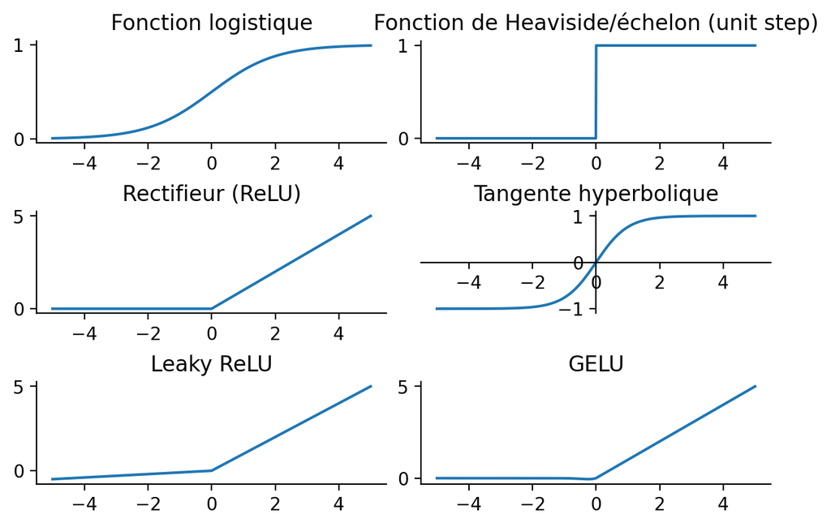

```python
x = np.linspace(-5, 5, 1000)

fig = plt.figure(dpi=200, constrained_layout=True)
axs = fig.subplots(3, 2)

axs[0, 0].plot(x, 1/(1+np.exp(-x)))
axs[0, 0].set_title("Fonction logistique")
axs[0, 1].plot(x, x > 0)
axs[0, 1].set_title("Fonction de Heaviside/échelon (unit step)")
axs[1, 0].plot(x, np.maximum(x, 0))
axs[1, 0].set_title("Rectifieur (ReLU)")
axs[1, 1].plot(x, np.tanh(x))
axs[1, 1].set_title("Tangente hyperbolique")
axs[1, 1].spines['left'].set_position('center')
axs[1, 1].spines['bottom'].set_position('zero')
axs[2, 0].plot(x, np.maximum(x, 0.1*x))
axs[2, 0].set_title("Leaky ReLU")
axs[2, 1].plot(x, np.maximum(x, 0.5*x*(1+np.tanh(np.sqrt(2*np.pi)*(x+0.044715*x**3)))))
axs[2, 1].set_title("GELU")

for ax in fig.get_axes():
    ax.spines["right"].set_color("none")
    ax.spines["top"].set_color("none")

plt.show()
```

Vous reconnaissez celle qu'on a utilisé dans notre réseau $\operatorname{XOR}$ ?

Et il y en a [plein](https://mlfromscratch.com/activation-functions-explained) d'autres.

En pratique, le choix de la bonne non-linéarité pour un réseau n'est pas encore bien compris : c'est un hyperparamètre à optimiser parmi d'autres. Ces dernières années on choisit plutôt par défaut la fonction rectifieur (dite un peu abusivement ReLU).

Mais au fait, pourquoi on s'embête avec ça ? Ça ne suffit pas des couches linéaires ?

Non.

Si on se limite à des couches linéaires, nos réseaux ne peuvent exprimer que des fonctions linéaires. Même si on peut faire beaucoup de choses avec, on a souvent besoin de plus. Voyez par exemple ce que ça donne dans [le bac à sable de Tensorflow](https://playground.tensorflow.org).

Si on utilise des non-linéarités, en revanche, nos réseaux deviennent beaucoup plus puissants. Beaucoup, **beaucoup** plus.

Le [**Théorème d'approximation universelle**](https://en.wikipedia.org/wiki/Universal_approximation_theorem), dont il existe de nombreuses versions (Pinkus, [1999](https://pinkus.net.technion.ac.il/files/2021/02/acta.pdf)) en fait une très bonne revue) dit en substance qu'à condition d'avoir assez de couches, ou des couches suffisament larges et d'utiliser des non-linéarités continues qui ne soient pas des polynômes, étant donnée une fonction continue $f$, on peut toujours trouver un réseau de neurones qui soit aussi près qu'on veut de $f$.

Bien que ça ne dise rien de la capacité des réseaux de neurones à *apprendre* des fonctions arbitraires, c'est une des motivations théoriques principales à leur utilisation : au moins, contrairement à un classifieur logistique par exemple, ils sont capables de représenter les fonctions qui nous intéressent.

Dernière précision : les couches linéaires et les non-linéarités par coordonnées ne sont pas les seules types de couches qu'on utilise en pratique. Notablement, pour construire des classifieurs multiclasses on utilise souvent la fonction $\operatorname{softmax}$ comme dernière couche.

$$\begin{equation} \operatorname{softmax}(z_1, …, z_n) = \left( \frac{e^{z_1}}{\sum_i e^{z_i}}, …, \frac{e^{z_n}}{\sum_i e^{z_i}} \right) \end{equation}$$

Au final, voici à quoi ressemble un classifieur neuronal classique.

```python
from scipy.special import softmax

class ReluLayer:
    """Une couche neuronale qui applique la fonction rectifieur"""
    def __call__(self, inpt):
        return np.maximum(inpt, 0)

class SoftmaxLayer:
    """Une couche neuronale qui applique la fonction softmax à son entrée"""
    def __call__(self, inpt):
        return softmax(inpt)

# Un réseau a une couche cachée de taille 32 qui prend en entrée des vecteurs
# de traits de dimension 16 et renvoie les vraisemblances de 8 classes.
# Les poids sont aléatoires
classifier = Network(
    [
        LinearLayer(np.random.normal(size=(32, 16)), np.random.normal(size=(32))),
        ReluLayer(),
        LinearLayer(np.random.normal(size=(8, 32)), np.random.normal(size=(8))),
        SoftmaxLayer(),
    ],
)

classifier([0, 2, 1, 3, 7, 0.1, 0.5, -12, 2, 1, -0.5, -1, 10
            , -2, 0.128, -8])
```

```
array([2.98975171e-15, 3.85632298e-53, 1.93934759e-04, 3.48067035e-20,
       2.35204656e-28, 6.47299530e-20, 1.59413682e-04, 9.99646652e-01])
```

[En pratique](https://ogunlao.github.io/2020/04/26/you_dont_really_know_softmax.html) comme $\operatorname{softmax}$ est toujours plutôt instable, on utilise plutôt $\log\operatorname{softmax}$, c'est toujours la même histoire.

## Apprendre un réseau de neurones

Tout ça c'est bien gentil, mais encore une fois, on a choisi des poids à la main. Or notre objectif c'est d'**apprendre**.

Comment on apprend un réseau de neurone ? Comment on détermine les poids à partir de données ?

Et bien c'est toujours la même recette pour l'apprentissage supervisé :

- Déterminer une fonction de coût
- Apprendre par descente de gradient

Les fonctions de coût ressemblent très fort à celles d'autres techniques d'apprentissage. En TAL, comme on s'en sort toujours plus ou moins pour se rammener à de la classification, on va en général utiliser la $\log$-vraisemblance négative, comme pour les classifieurs logistiques.

Concrètement, qu'est-ce que ça donne ? Et bien si on a un réseau de neurones $f$ pour un problème à $n$ classes (donc qui renvoie en sortie des vecteurs normalisés de dimension $n$) et un exemple $(x, y)$ où $x$ est une entrée adaptée à $f$ et $1⩽y⩽n$ est la classe à prédire pour $x$, la loss de $f$ pour $(x, y)$ sera

$$\begin{equation} L(f, x, y) = -\log\left(f(x)_y\right) \end{equation}$$

où $f(x)_y$ est la $y$-ième coordonnée de $f(x)$.

C'est aussi pour ça qu'on aime bien utiliser le $\log\operatorname{softmax}$ : de toute façon on va vouloir calculer un $\log$ après.

Ok, et le gradient ?

Ça se corse un peu mais pas trop.

On va utiliser les mêmes idées que celles qu'on a vu pour les classifieurs logistiques : on va considérer un paramètre $θ$ qui sera une concaténation de tous les poids de toutes les couches du réseau dans un gros vecteur et les les $L(f, x, y)$ comme des fonctions de $θ$.

Par bonheur, si les non-linéarités qu'on a choisi sont gentilles (et elles le sont, on les choisit pour), ces fonctions seront différentiables, c'est-à-dire qu'elles ont un gradient pour tout $(x, y)$ et on peut donc leur appliquer l'algorithme de descente de gradient stochastique.

Alors quel est le problème ?

Il y en a deux :

1. Comment on calcule ces gradients ?
2. Est-ce que l'algorithme fonctionne toujours ?

Le point 1. n'est pas un problème, les fonctions en questions peuvent être compliquées, surtout si le réseau est profond, et caculer leur gradients à la main ça peut être pénible, mais heureusement on a des programmes de calcul symbolique qui ont la gentillesse de le faire pour nous. C'est ce qu'on appelle de la **différentiation automatique** dont on va voir un exemple juste après.

Le point 2. est plus délicat en théorie : on a pas de garantie théorique que l'algo fonctionne toujours, ni même réellement d'estimation de son comportement. Mais **en pratique** ça a tendance à marcher la plupart du temps : si on applique l'algo de descente de gradient avec des hyperparamètres raisonnables et suffisament de données, on arrive à trouver des bons poids.

Un [certain](https://ruder.io/optimizing-gradient-descent/) nombre de raffinement de cet algo (que vous trouverez souvent sous le nom *SGD* pour **S**tochastic **G**radient **D**escent) ont été développé pour essayer que ça marche le mieux possible le plus souvent possible. Deux particulièrement notables sont l'accelération de Nesterov et l'estimation adaptative des moments ([Adam](https://arxiv.org/abs/1412.6980)).

## En pratique 🔥

En pratique, comme on ne va certainement pas implémenter tout ça à la main ici (même si je vous recommande de le faire une fois de votre côté pour bien comprendre comment ça marche), on va se reposer sur la bibliothèque de réseaux de neurones la plus utilisée pour le TAL ces dernières (et probablement aussi ces prochaines) années : Pytorch.

```python
import torch
```

Pytorch fait plein de choses (allez voir la [doc](https://pytorch.org/docs)), mais pour commencer, on va l'utiliser comme une collection de couches neuronales et une bibliothèque de calcul vectoriel (comme numpy).

### Les tenseurs

L'objet de base dans Pytorch est le **tenseur** `torch.tensor`, qui est un autre nom pour ce que numpy appelle un `array`.

```python
t = torch.tensor([1,2,3,4])
t
```

```
tensor([1, 2, 3, 4])
```

```python
t = torch.tensor(
    [
        [1,2,3,4],
        [5,6,7,8],
    ]
)
t
```

```
tensor([[1, 2, 3, 4],
        [5, 6, 7, 8]])
```

D'ailleurs on peut facilement faire des allers-retours entre Pytorch et Numpy

```python
torch.tensor([1,2,3,4]).numpy()
```

```
array([1, 2, 3, 4])
```

```python
torch.from_numpy(np.array([1,2,3,4]))
```

```
tensor([1, 2, 3, 4])
```

Comme les tableaux numpy, on peut leur appliquer des opérations

```python
torch.tensor([1,2,3,4]) + torch.tensor([1,5,-2,-1])
```

```
tensor([2, 7, 1, 3])
```

Et la plupart des opérations définies dans numpy sont disponible ici aussi (Pytorch essaie autant que possible d'être compatible)

```python
torch.sum(torch.tensor([1,2,3,4]))
```

```
tensor(10)
```

Même si en général, on y préfère un style d'opérations en chaînes

```python
torch.tensor([1,2,3,4]).mul(torch.tensor(2)).sum()
```

```
tensor(20)
```

Vous trouverez dans la doc [la liste des fonctions natives](https://pytorch.org/docs/stable/torch.html) et celle des [méthodes des tenseurs](https://pytorch.org/docs/stable/tensors.html), n'hésitez pas à vous y pencher souvent, surtout avant de vouloir recoder des trucs vous mêmes.

### Les couches neuronales

Les couches neuronales sont définies dans le module [`torch.nn`](https://pytorch.org/docs/stable/nn.html).

```python
import torch.nn
```

Il y en a beaucoup

```python
len(dir(torch.nn))
```

```
180
```

En pratique, Pytorch ne fait pas la différence entre un réseau et une couche : tout ça sera un `torch.nn.Module`. L'avantage c'est que ça permet facilement d'interconnecter des réseaux entre eux.

La couche la plus importante pour nous ici c'est la couche [`torch.nn.Linear`](https://pytorch.org/docs/stable/generated/torch.nn.Linear.html) qui est évidemment la couche linéaire complètement connectée qu'on a appellé `LinearLayer` plus haut.

Voici une réimplémentation du réseau $\operatorname{XOR}$ en Pytorch (c'est un peu laborieux parce que Pytorch n'est pas vraiment prévu pour coder des poids en dur, mais c'est possible !)

```python
layer1 = torch.nn.Linear(2, 2)
layer1.weight = torch.nn.Parameter(torch.tensor([[0.5, 0.5], [1, 1]]))
layer1.bias = torch.nn.Parameter(torch.tensor([-0.6, -0.5]))
layer2 = torch.nn.Linear(2, 2)
layer2.weight = torch.nn.Parameter(torch.tensor([[-1.0, 0.0], [0.0, 1.0]]))
layer2.bias = torch.nn.Parameter(torch.tensor([1.0, 0.0]))
layer3 = torch.nn.Linear(2, 2)
layer3.weight = torch.nn.Parameter(torch.tensor([[0.5, 0.5]]))
layer3.bias = torch.nn.Parameter(torch.tensor([-0.6]))

# Pas de couche correspondant à la fonction de Heaviside en Pytorch, il faut la coder nous même !
class StepLayer(torch.nn.Module):
    def forward(self, inpt):
        return torch.heaviside(inpt, torch.tensor(0.0))

xor_ffnn = torch.nn.Sequential(
    layer1, StepLayer(), layer2, StepLayer(), layer3, StepLayer()
)

print("x\ty\tx XOR y")
for x_i in [0.0, 1.0]:
    for y_i in [0.0, 1.0]:
        with torch.no_grad():
            out = xor_ffnn(torch.tensor([x_i, y_i]))
        print(f"{x_i}\t{y_i}\t{out}")
```

```
x	y	x XOR y
0.0	0.0	tensor([0.])
0.0	1.0	tensor([1.])
1.0	0.0	tensor([1.])
1.0	1.0	tensor([0.])
```

On peut remarque que la définition du calcul fait par une couche ne se fait pas directement en implémentant `__call__` mais `forward` (le nom vient de l'idée que dans un réseau les données **avancent** à travers les différentes couches). Pytorch fait plein de magie pour que l'utilisation des algos d'apprentissage soit aussi laconique que possible, et une de ses astuces c'est qu'il définit lui-même `__call__` en prenant le `forward` défini par vous et en faisant d'autres trucs autour.

## Entraînement 🔥

Pour entraîner un réseau en Pytorch, on peut presque directement traduire l'algo de descente de gradient stochastique. Voici par exemple comment on peut entraîner un réseau à trois couches logistiques de deux neurones à apprendre la fonction $\operatorname{XOR}$

On commence par définir un jeu de données d'apprentissage

```python
train_set = [
    (torch.tensor([0.0, 0.0]), torch.tensor([0.])),
    (torch.tensor([0.0, 1.0]), torch.tensor([1.0])),
    (torch.tensor([1.0, 0.0]), torch.tensor([1.0])),
    (torch.tensor([1.0, 1.0]), torch.tensor([0.0])),
]
```

Le réseau

```python
# Dans une fonction comme ça c'est facile de le réinitialiser pour relancer un apprentissage
def get_xor_net():
    return torch.nn.Sequential(
        torch.nn.Linear(2, 2),
        torch.nn.Sigmoid(),
        torch.nn.Linear(2, 2),
        torch.nn.Sigmoid(),
        torch.nn.Linear(2, 1),
        torch.nn.Sigmoid(),
    )
get_xor_net()
```

```
Sequential(
  (0): Linear(in_features=2, out_features=2, bias=True)
  (1): Sigmoid()
  (2): Linear(in_features=2, out_features=2, bias=True)
  (3): Sigmoid()
  (4): Linear(in_features=2, out_features=1, bias=True)
  (5): Sigmoid()
)
```

Et on traduit l'algo

```python
import torch.optim

xor_net = get_xor_net()
# SGD est déjà implémenté, sous la forme d'un objet auquel on
# passe les paramètres à optimiser : ici les poids du réseau
optim = torch.optim.SGD(xor_net.parameters(), lr=0.03)

print("Epoch\tLoss")

# Apprendre XOR n'est pas si rapide, on va faire 50 000 epochs
loss_history = []
for epoch in range(50000):
    # Pour l'affichage
    epoch_loss = 0.0
    # On parcourt le dataset
    for inpt, target in train_set:
        # Le réseau prédit une classe
        output = xor_net(inpt)
        # On mesure son erreur avec la log-vraisemblance négative
        loss = torch.nn.functional.binary_cross_entropy(output, target)
        # On calcule le gradient de la loss par rapport à chacun des
        # paramètres en ce point.
        # `backward` parce qu'on utilise l'algo de rétroprogation du gradient
        loss.backward()
        # On applique un pas de l'algo de descente de gradient
        # C'est ici qu'on modifie les poids
        optim.step()
        # On doit remettre les gradients des paramètres à zéro, sinon ils
        # s'accumulent quand on appelle `backward`
        optim.zero_grad()
        # Pour l'affichage toujours
        epoch_loss += loss.item()
    loss_history.append(epoch_loss)
    if not epoch % 1000:
        print(f"{epoch}\t{epoch_loss}")

print("x\ty\tx XOR y")
for x_i in [0.0, 1.0]:
    for y_i in [0.0, 1.0]:
        with torch.no_grad():
            out = xor_net(torch.tensor([x_i, y_i]))
        print(f"{x_i}\t{y_i}\t{out}")
```

```
Epoch	Loss
0	2.895171582698822
1000	2.792667031288147
2000	2.792290687561035
3000	2.7919477820396423
4000	2.791636049747467
5000	2.791352927684784
6000	2.7910961508750916
7000	2.7908636331558228
8000	2.790652334690094
9000	2.7904608249664307
10000	2.790286898612976
11000	2.7901286482810974
12000	2.7899844646453857
13000	2.7898529767990112
14000	2.789732575416565
15000	2.7896223068237305
16000	2.789521276950836
17000	2.789428174495697
18000	2.7893426418304443
19000	2.789263427257538
20000	2.789190173149109
21000	2.789122462272644
22000	2.789059340953827
23000	2.789000928401947
24000	2.788945972919464
25000	2.788895070552826
26000	2.7888473868370056
27000	2.788802683353424
28000	2.7887608408927917
29000	2.788721442222595
30000	2.788684129714966
31000	2.788649260997772
32000	2.788616418838501
33000	2.788585066795349
34000	2.788555860519409
35000	2.788527727127075
36000	2.7885013222694397
37000	2.7884761095046997
38000	2.7884522080421448
39000	2.7884294390678406
40000	2.7884077429771423
41000	2.7883869409561157
42000	2.788367211818695
43000	2.788348138332367
44000	2.788329839706421
45000	2.788312256336212
46000	2.78829562664032
47000	2.788279712200165
48000	2.7882641553878784
49000	2.788249373435974
x	y	x XOR y
0.0	0.0	tensor([0.5001])
0.0	1.0	tensor([0.5002])
1.0	0.0	tensor([0.4998])
1.0	1.0	tensor([0.4999])
```

Félicitations, vous venez d'apprendre un réseau de neurones et de vous adonner à la célèbre tradition dite « regarder avec anxiété la loss en espérant qu'elle descende ».

Et elle est bien descendue, n'est-ce pas ?

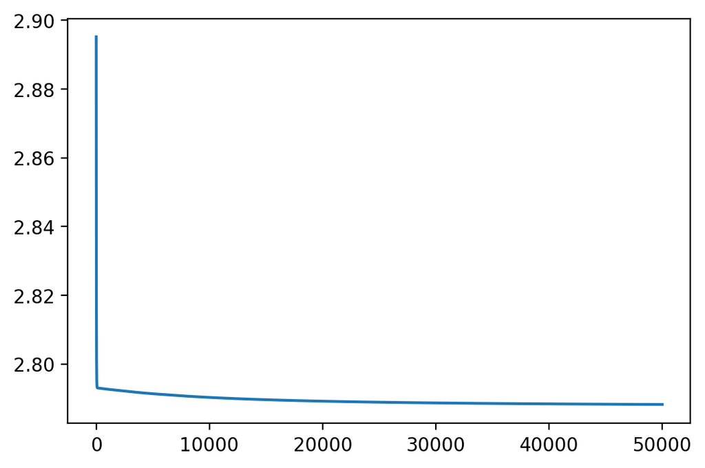

```python
fig = plt.figure(dpi=200)
plt.plot(loss_history)
plt.show()
```

Qu'est-ce que ça donne comme poids ? Regardons :

```python
for p in xor_net.parameters():
    print(p.data)
```

```
tensor([[-0.0270, -0.1575],
        [ 0.2736, -0.0373]])
tensor([0.1044, 0.2390])
tensor([[-0.4735, -0.7136],
        [-0.1715, -0.5301]])
tensor([-1.2267, -1.3656])
tensor([[0.0912, 0.1680]])
tensor([-0.0367])
```

Est-ce qu'on peut en tirer des conclusions ? Pas sûr !

On peut au moins regarder la heatmap

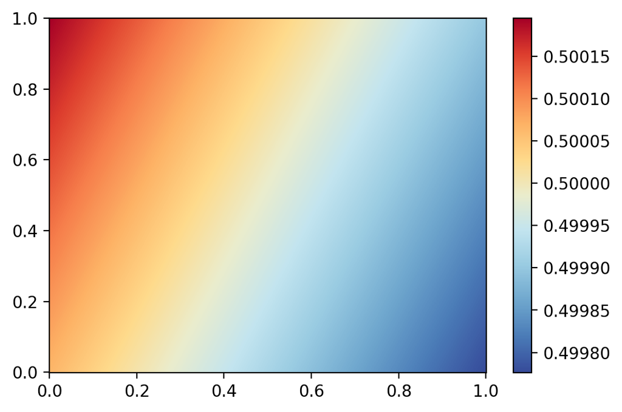

```python
x = np.linspace(0, 1, 1000, dtype=np.float64)
y = np.linspace(0, 1, 1000, dtype=np.float64)
X, Y = np.meshgrid(x, y)
inpt = torch.stack((torch.from_numpy(X), torch.from_numpy(Y)), dim=-1).to(torch.float)
with torch.no_grad():
    Z = xor_net(inpt).squeeze().numpy()

fig = plt.figure(dpi=200)

heatmap = plt.pcolormesh(X, Y, Z, shading="auto", cmap=tc.tol_cmap("sunset"))
plt.colorbar(heatmap)
plt.show()
```

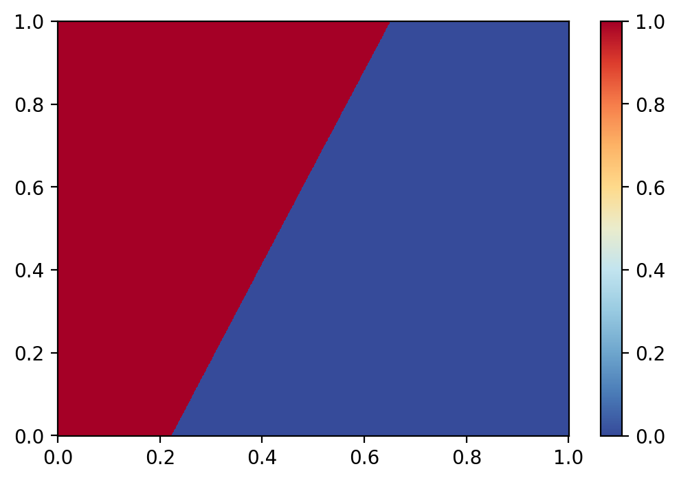

```python
x = np.linspace(0, 1, 1000, dtype=np.float64)
y = np.linspace(0, 1, 1000, dtype=np.float64)
X, Y = np.meshgrid(x, y)
inpt = torch.stack((torch.from_numpy(X), torch.from_numpy(Y)), dim=-1).to(torch.float)
with torch.no_grad():
    Z = xor_net(inpt).gt(0.5).squeeze().numpy()

fig = plt.figure(dpi=200)

heatmap = plt.pcolormesh(X, Y, Z, shading="auto", cmap=tc.tol_cmap("sunset"))
plt.colorbar(heatmap)
plt.show()
```

## Aller plus loin

La tradition veut qu'on commence par entraîner un modèle sur le jeu de données MNIST : suivez [le tutoriel de towards datascience](https://towardsdatascience.com/handwritten-digit-mnist-pytorch-977b5338e627) (une source pas toujours excellente mais dans ce cas précis ça va.

On fait du TAL ici ! Et langage ? Et bien en pratique c'est un peu plus compliqué à traiter que les images ou les nombres. On se penchera davantage dessus la prochaine fois, mais pour l'instant vous pouvez faire un peu de classification de documents avec [le tutoriel de torchtext](https://pytorch.org/tutorials/beginner/text_sentiment_ngrams_tutorial.html) (qui n'est pas une bibliothèque très souvent populaire, mais elle est bien utile ici. Microsoft propose [un tutorial similaire](https://docs.microsoft.com/en-us/learn/modules/intro-natural-language-processing-pytorch).

Un peu de lecture : [*Natural Language Processing (almost) from scratch](https://dl.acm.org/doi/10.5555/1953048.2078186) (Collobert et al., 2011).

[Une super série de vidéo](https://youtube.com/playlist?list=PLZHQObOWTQDNU6R1_67000Dx_ZCJB-3pi) avec de belles visus sur [la chaîne YouTube 3blue1brown](https://www.youtube.com/c/3blue1brown).